# Week2_1

## Introduction

Plots are powerful in revealing information in data. Data visualization is central to biologica. data analysis. We will learn how to make plots using ggplot2 in this lecture using COVID data as an example.

```r
library(ggplot2)
library(dplyr)
library(readr)
```

## ggplot2

In short, ggplot2 = data + aesthetics (aes) + geometries (geom) + facets (optional) + stats (optional) + coord (optional) + theme (optional). Let’s see an example by plotting daily COVID-19 cases in the US.

```r
dat = read_csv("../Week2/data/compact.csv")
```

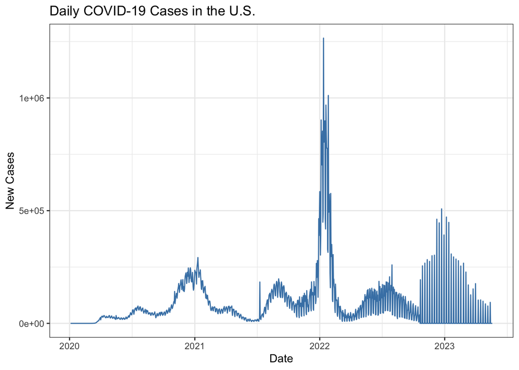

```r
dat %>% filter(country == "United States" & !is.na(new_cases)) %>%
       ggplot(aes(x = date, y = new_cases)) +
  geom_line(color = "steelblue") +
  labs(title = "Daily COVID-19 Cases in the U.S.",
       x = "Date", y = "New Cases") + theme_bw()
```

As we have learned in the Week 2, the first line filters data by keeeping only rows where the country is US and new cases are not missing (NA). We then pass the data to ggplot by the pipe operator `%>%`. We set up aes mapping in the `ggplot` function, where we specify the column of the data to be plotted on the x and y axis. In ggplot2, graphs are created by adding layers defined by geommetris (geom). Here, we draw lines connecting each data points. Alternatively, please refer to [this](https://posit.co/wp-content/uploads/2022/10/data-visualization-1.pdf) cheatsheet for more types of graphs. Finally, we add the title and axis labels for readability, and use a black and white theme for a clean look.

## Types of plot

We next show how to make some commonly used plots.

### Scatterplot

Scatterplot displays values for typically two quantitative variables to identify the relationship.

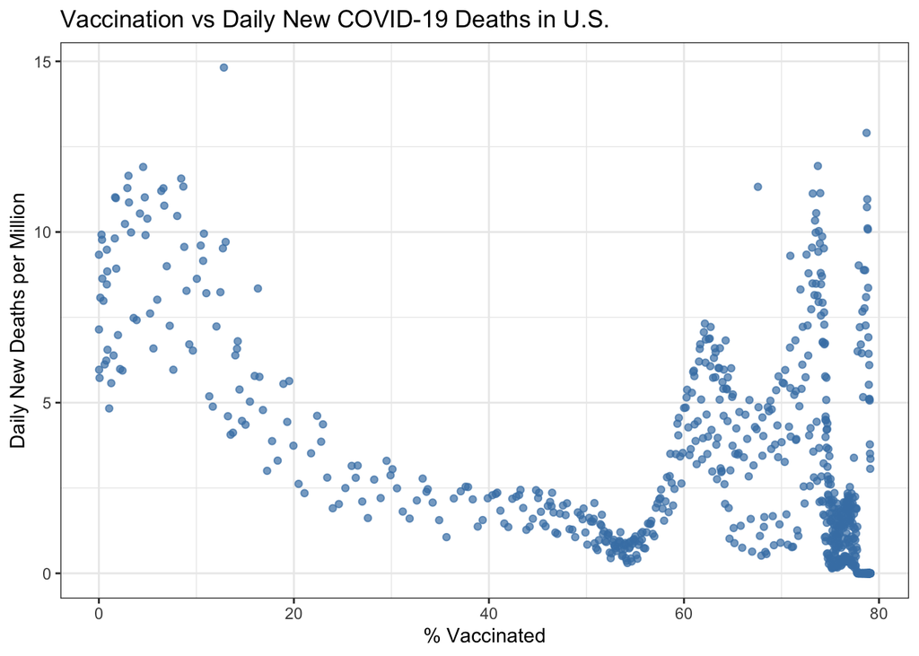

```r
dat %>% filter(country == "United States" & !is.na(people_vaccinated_per_hundred), !is.na(new_cases_per_million)) %>%
  ggplot(aes(x = people_vaccinated_per_hundred, y = new_deaths_per_million)) +
  geom_point(alpha = 0.7, color = "steelblue") +
  labs(title = "Vaccination vs Daily New COVID-19 Deaths in U.S.",
       x = "% Vaccinated", y = "Daily New Deaths per Million") +
  theme_bw()
```

We see that generally in the early to mid stages, new deaths declined as vaccination rate increased. However, later waves showed that new deaths increased despite of high vaccination coverage, possibly due to a combination of factors such as emergence of new variants (Delta in mid-2021 and Omicron in late 2021/2022), waning immunity from vaccines, uneven vaccination coverage and behavioral/policy changes (e.g. lift of mask mandates, distancing, travel).

## AI assisted ggplot2

Color by groups

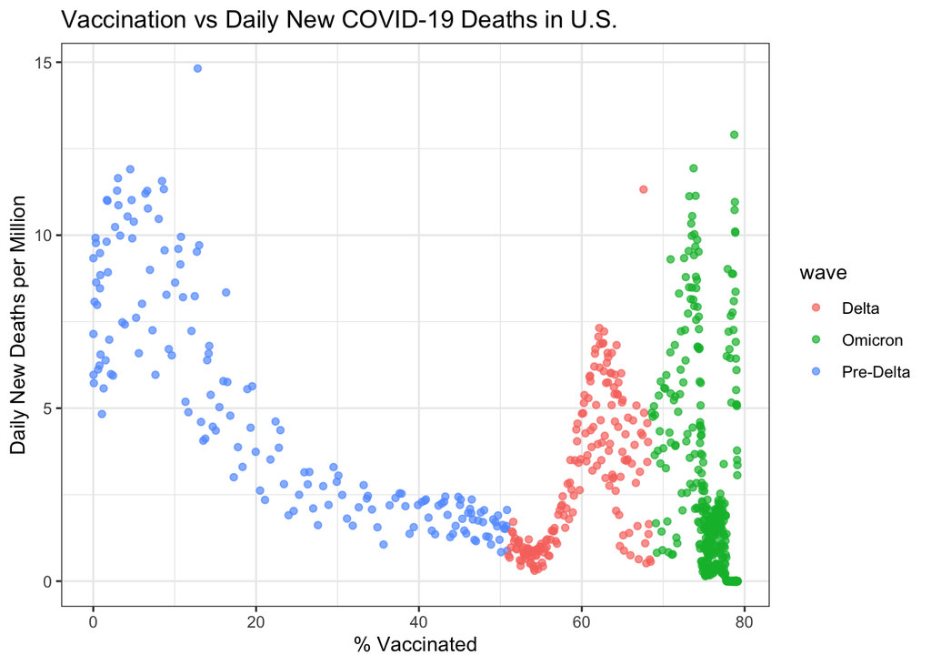

```r
dat %>% filter(country == "United States" & !is.na(people_vaccinated_per_hundred), !is.na(new_cases_per_million)) %>%
  mutate(date = as.Date(date),
         wave = case_when(
           date < as.Date("2021-06-01") ~ "Pre-Delta",
           date >= as.Date("2021-06-01") & date < as.Date("2021-12-01") ~ "Delta",
           date >= as.Date("2021-12-01") ~ "Omicron"
         )) %>%
  ggplot(aes(x = people_vaccinated_per_hundred, y = new_deaths_per_million, color = wave)) +
  geom_point(alpha = 0.7) +
  labs(title = "Vaccination vs Daily New COVID-19 Deaths in U.S.",
       x = "% Vaccinated", y = "Daily New Deaths per Million") +
  theme_bw()
```